# Practicum 11: Machine Learning - Supervised Methods

Data Science for Biomedical Informatics (BMIN503/EPID600)

New packages to install for this practicum:

```r
install.packages("e1071")
install.packages("randomForest")
install.packages("glmnet")
```

We will create predictive models with SVM, random forests, and Lasso to predict titanic survivorship using the dataset about [Titanic passengers](http://biostat.mc.vanderbilt.edu/wiki/pub/Main/DataSets/titanic.html) used last time. The data dictionary to understand file variables is [here](https://github.com/HimesGroup/BMIN503/blob/master/DataFiles/titanic3.md).

```r
library(tidyverse)
titanic <- read.csv(url("https://raw.githubusercontent.com/HimesGroup/BMIN503/master/DataFiles/titanic3.csv"), header=TRUE)
titanic <- titanic %>%
    select(survived, pclass, sex, age, sibsp, parch) %>%
    filter(complete.cases(.)) %>%
    mutate(survived = factor(survived, levels=c(0, 1), labels=c("died", "lived"))) %>%
    mutate(pclass = factor(pclass, levels=c(1, 2, 3), labels=c("first", "second", "third")))
str(titanic)
```

```
## 'data.frame':    1046 obs. of  6 variables:
##  $ survived: Factor w/ 2 levels "died","lived": 2 2 1 1 1 2 2 1 2 1 ...
##  $ pclass  : Factor w/ 3 levels "first","second",..: 1 1 1 1 1 1 1 1 1 1 ...
##  $ sex     : Factor w/ 2 levels "female","male": 1 2 1 2 1 2 1 2 1 2 ...
##  $ age     : num  29 0.92 2 30 25 48 63 39 53 71 ...
##  $ sibsp   : int  0 1 1 1 1 0 1 0 2 0 ...
##  $ parch   : int  0 2 2 2 2 0 0 0 0 0 ...
```

```r
x.factors <- model.matrix(titanic$survived ~ titanic$sex + titanic$pclass)[, -1]
titanic.df <- cbind(titanic[, c("survived", "age", "sibsp", "parch")], x.factors)
names(titanic.df)[5:7] <- c("sexmale", "pclass2", "pclass3")
x <- as.matrix( cbind(titanic[, c("age", "sibsp", "parch")], x.factors) )
```

### Support Vector Machine (SVM)

One package that can create SVMs is (`e1071`)[https://www.rdocumentation.org/packages/e1071/versions/1.7-0/topics/svm]. Although not widely used, SVM are one of the simplest machine learning approaches to understand, at least in their simplied form. If you read the description of the SVM package, you will see that there are many parameters that can be tuned.

```r
library(e1071)
titanic.svm <- svm(survived ~ ., data=titanic.df, scale=TRUE, kernel="linear")
titanic.svm
```

```
##
## Call:
## svm(formula = survived ~ ., data = titanic.df, kernel = "linear",
##     scale = TRUE)
##
##
## Parameters:
##    SVM-Type:  C-classification
##  SVM-Kernel:  linear
##        cost:  1
##       gamma:  0.1666667
##
## Number of Support Vectors:  477
```

```r
svm.pred <- fitted(titanic.svm)
table(titanic$survived, svm.pred)
```

```
##        svm.pred
##         died lived
##   died   523    96
##   lived  135   292
```

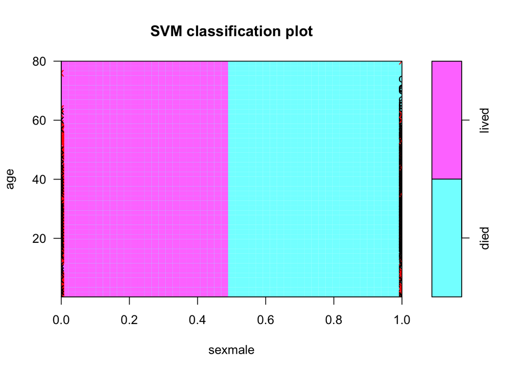

```r
plot(titanic.svm, titanic.df, age ~ sexmale)
```

```r
titanic.svm <- svm(survived ~ ., data=titanic.df, scale=TRUE, kernel="radial")
svm.pred <- fitted(titanic.svm)
table(titanic$survived, svm.pred)
```

```
##        svm.pred
##         died lived
##   died   580    39
##   lived  148   279
```

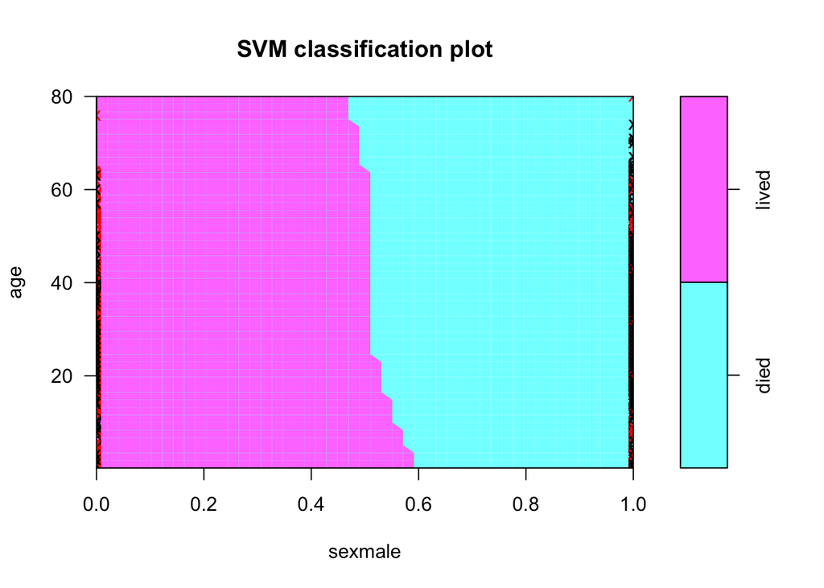

```r
plot(titanic.svm, titanic.df, age ~ sexmale)
```

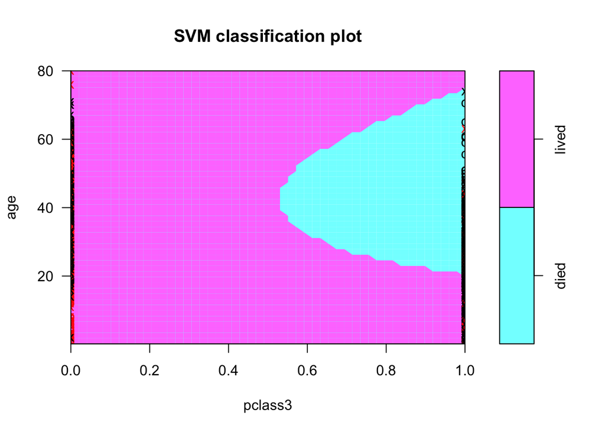

```r
plot(titanic.svm, titanic.df, age ~ pclass3)
```

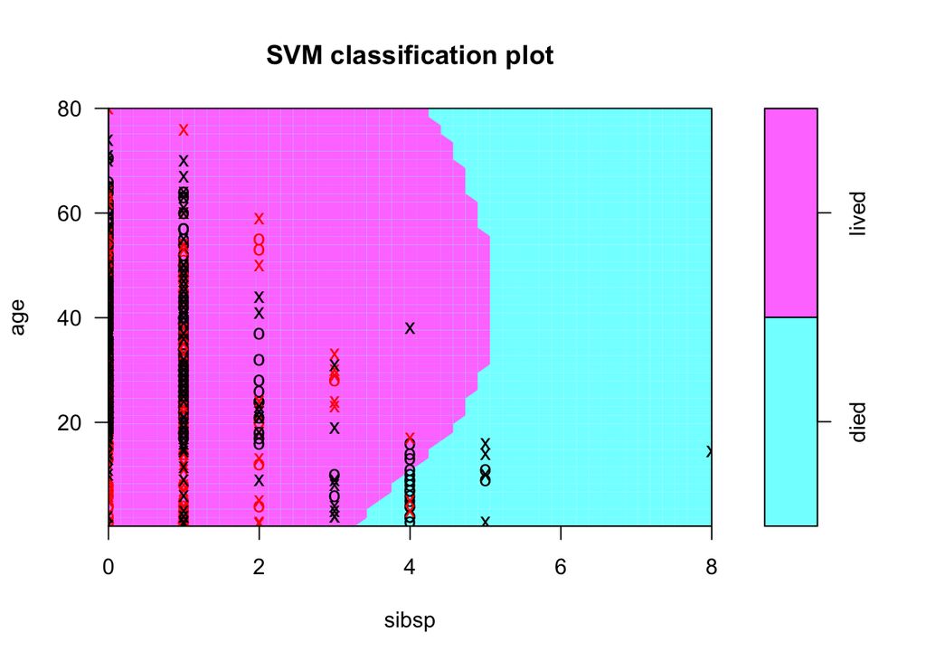

```r
plot(titanic.svm, titanic.df, age ~ sibsp)
```

```r
titanic.svm <- svm(survived ~ ., data=titanic.df, scale=TRUE, kernel="radial", probability=TRUE)
svm.pred <- predict(titanic.svm, titanic.df, probability=TRUE)
svm.pred.lived <- attr(svm.pred, "probabilities")[, 1]
```

### Random Forest

Random forests are a perferred supervised approach. If random forests are new to you, I recommend this intuitive visual illustration of [how a decision tree works](http://www.r2d3.us/visual-intro-to-machine-learning-part-1/). A random forest consists of many such trees created with portions of data from an entire dataset. The authors of Random Forests have a [detailed description](https://www.stat.berkeley.edu/~breiman/RandomForests/cc_home.htm) of how they work along with descriptions of measures obtained.

```r
library(randomForest)
titanic.rf <- randomForest(survived ~ ., data=titanic.df, ntree=100, importance=TRUE)
titanic.rf
```

```
##
## Call:
##  randomForest(formula = survived ~ ., data = titanic.df, ntree = 100,      importance = TRUE)
##                Type of random forest: classification
##                      Number of trees: 100
## No. of variables tried at each split: 2
##
##         OOB estimate of  error rate: 20.65%
## Confusion matrix:
##       died lived class.error
## died   566    53  0.08562197
## lived  163   264  0.38173302
```

```r
titanic.rf$importance
```

```
##               died        lived MeanDecreaseAccuracy MeanDecreaseGini
## age     0.02461158  0.027786371          0.025897111        44.888538
## sibsp   0.01905806 -0.003774205          0.009742197        14.866653
## parch   0.02145844  0.003915530          0.014274054        14.690375
## sexmale 0.12965815  0.211396508          0.162944619       124.388731
## pclass2 0.02109376 -0.002506259          0.011448831         9.614015
## pclass3 0.05399380  0.072376611          0.061707256        37.317047
```

```r
titanic.rf.pred <- predict(titanic.rf, titanic.df, type="prob")
head(titanic.rf.pred)
```

```
##   died lived
## 1 0.02  0.98
## 2 0.14  0.86
## 3 0.41  0.59
## 4 0.79  0.21
## 5 0.19  0.81
## 6 0.92  0.08
```

```r
rf.pred.lived <- titanic.rf.pred[, 2]
```

### Lasso regression model

The least absolute shrinkage and selection operator (Lasso) is a type of regression analysis that will select the best coefficients that can be used to predict an outcome variable by “shrinking” some of the coefficients. You can read about the specific function that is being optimized to obtain the coeffecients via the resources [here](http://statweb.stanford.edu/~tibs/lasso.html). The [glmnet](https://cran.r-project.org/web/packages/glmnet/index.html) package contains Lasso and other functions to obtain regression models that are appropriate when needing to select among many predictors. The `lambda` parameter, which needs to be selected, can be chosen using cross-validation with the `cv.glmnet` function.

```r
library(glmnet)
set.seed(1234)
titanic.lasso <- cv.glmnet(x, y=titanic$survived, alpha=1, family="binomial")
titanic.lasso$lambda.min
```

```
## [1] 0.0009071174
```

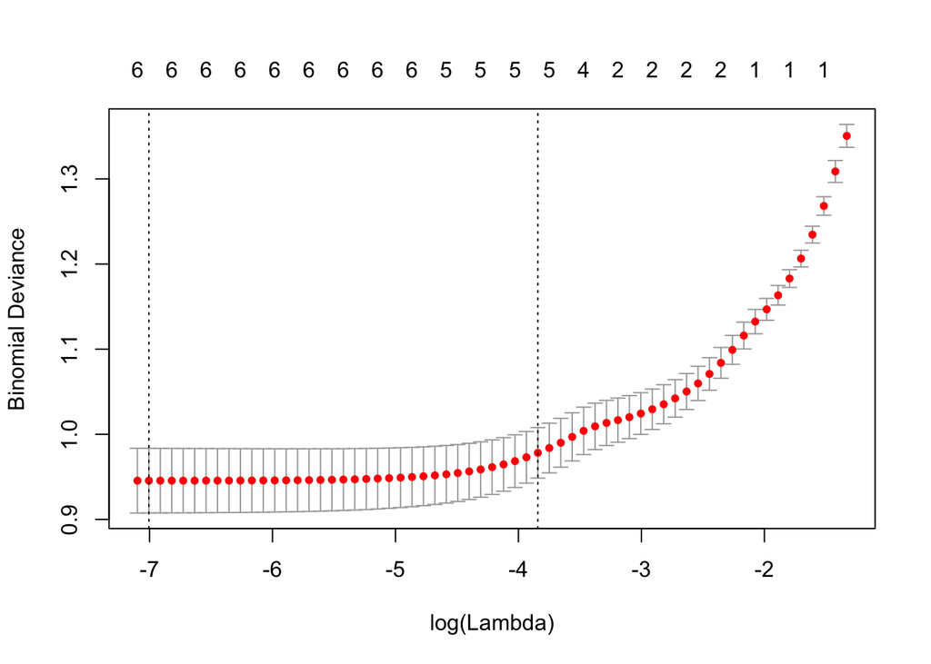

```r
plot(titanic.lasso)
```

```r
lasso.coef <- coef(titanic.lasso, s="lambda.min")
titanic.lasso.pred <- predict(titanic.lasso, x, s="lambda.min", type="response")
head(titanic.lasso.pred)
```

```
##           1
## 1 0.9373432
## 2 0.7380214
## 3 0.9715245
## 4 0.4818152
## 5 0.9342018
## 6 0.3649018
```

### Model Evaluation

We use the same approach as that used in practicum 10.

```r
#K-Fold Cross Validation
N = nrow(titanic)
K = 10
set.seed(1234)
s = sample(1:K, size=N, replace=T)
pred.outputs.svm <- vector(mode="numeric", length=N)
pred.outputs.rf <- vector(mode="numeric", length=N)
pred.outputs.lasso <- vector(mode="numeric", length=N)
obs.outputs <- vector(mode="numeric", length=N)
offset <- 0
for(i in 1:K){
    train <- filter(titanic.df, s != i)
    test <- filter(titanic.df, s == i)
    obs.outputs[1:length(s[s==i]) + offset] <- test$survived

    #SVM train/test
    svm.m <- svm(survived~., data=train, scale=TRUE, kernel="radial", probability=TRUE)
    svm.pred.curr <- predict(svm.m, test, probability=TRUE)
    pred.outputs.svm[1:length(s[s==i]) + offset] <- attr(svm.pred.curr, "probabilities")[,1]

    #RF train/test
    rf <- randomForest(survived~., data=train, ntree=100)
    rf.pred.curr <- predict(rf, newdata=test, type="prob")
    pred.outputs.rf[1:length(s[s==i]) + offset] <- rf.pred.curr[,2]

    #lasso train/test
    lasso.m <- cv.glmnet(as.matrix(train[, -1]), y=train[, 1], alpha=1, family="binomial")
    lasso.pred.curr <- predict(lasso.m, as.matrix(test[, -1]), s="lambda.min", type="response")
    pred.outputs.lasso[1:length(s[s==i]) + offset] <- lasso.pred.curr[,1]

    offset <- offset + length(s[s==i])
}
```

### ROC Curves

ROC Curves provide an intuitive display of how well a predictive test performs over all possible thresholds that can be used to divide two outcomes. One R package that can create ROC curves and compute associated areas under the ROC curves (AUCs) and confidence intervals is `pROC`.

```r
library(pROC)
#SVM
roc(obs.outputs, pred.outputs.svm, ci=TRUE)
```

```
##
## Call:
## roc.default(response = obs.outputs, predictor = pred.outputs.svm,     ci = TRUE)
##
## Data: pred.outputs.svm in 619 controls (obs.outputs 1) < 427 cases (obs.outputs 2).
## Area under the curve: 0.828
## 95% CI: 0.8009-0.8552 (DeLong)
```

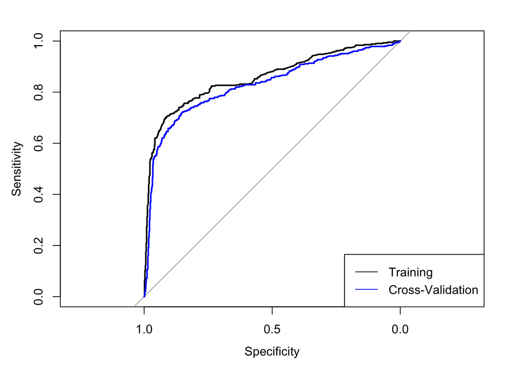

```r
plot.roc(titanic$survived, svm.pred.lived)
plot.roc(obs.outputs, pred.outputs.svm, ci=TRUE, col="blue", add=TRUE)
legend("bottomright", legend=c("Training", "Cross-Validation"), col=c("black", "blue"), lwd=1)
```

```r
#Random Forest
roc(obs.outputs, pred.outputs.rf, ci=TRUE)
```

```
##
## Call:
## roc.default(response = obs.outputs, predictor = pred.outputs.rf,     ci = TRUE)
##
## Data: pred.outputs.rf in 619 controls (obs.outputs 1) < 427 cases (obs.outputs 2).
## Area under the curve: 0.8394
## 95% CI: 0.8131-0.8658 (DeLong)
```

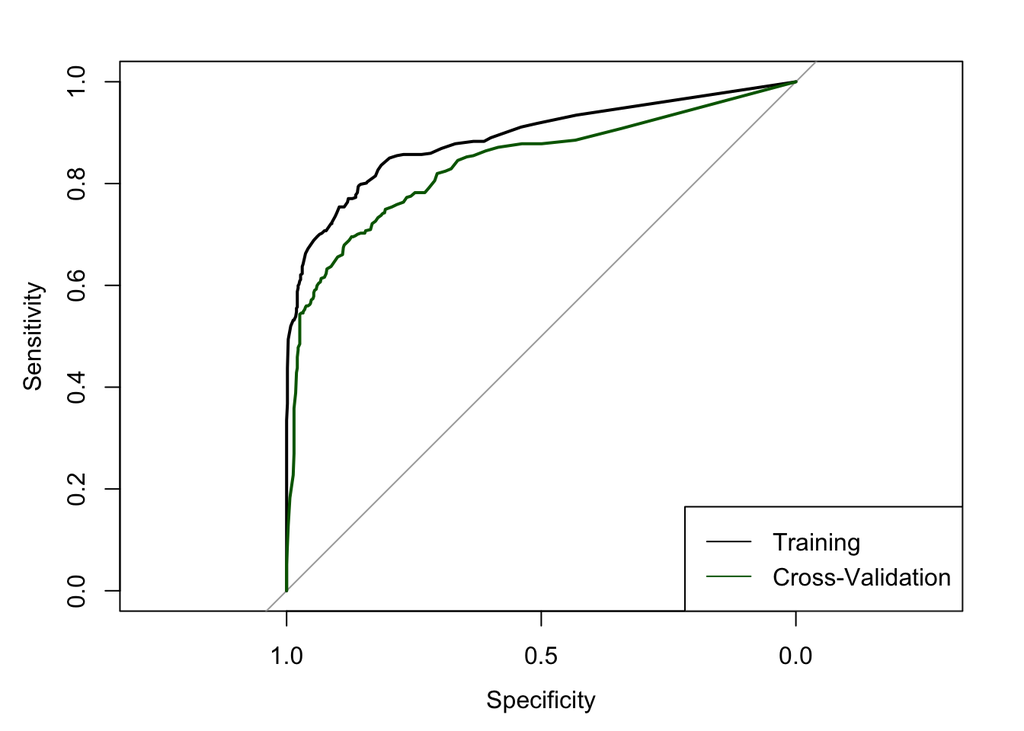

```r
plot.roc(titanic$survived, rf.pred.lived)
plot.roc(obs.outputs, pred.outputs.rf, ci=TRUE, col="darkgreen", add=TRUE)
legend("bottomright", legend=c("Training", "Cross-Validation"), col=c("black", "darkgreen"), lwd=1)
```

```r
#Lasso
roc(obs.outputs, pred.outputs.lasso, ci=TRUE)
```

```
##
## Call:
## roc.default(response = obs.outputs, predictor = pred.outputs.lasso,     ci = TRUE)
##
## Data: pred.outputs.lasso in 619 controls (obs.outputs 1) < 427 cases (obs.outputs 2).
## Area under the curve: 0.8431
## 95% CI: 0.8177-0.8685 (DeLong)
```

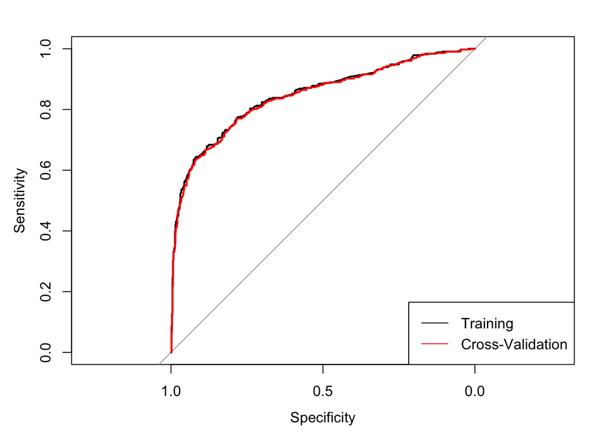

```r
plot.roc(titanic$survived, titanic.lasso.pred[,1])
plot.roc(obs.outputs, pred.outputs.lasso, ci=TRUE, col="red", add=TRUE)
legend("bottomright", legend=c("Training", "Cross-Validation"), col=c("black", "red"), lwd=1)
```

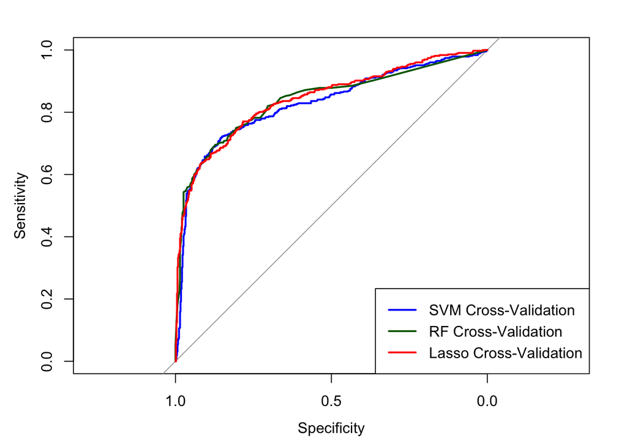

```r
#Plot both cross-validation ROCs
plot.roc(obs.outputs, pred.outputs.svm, ci=TRUE, col="blue") #CV of svm
plot.roc(obs.outputs, pred.outputs.rf, ci=TRUE, col="darkgreen", add=TRUE) #CV of rf
plot.roc(obs.outputs, pred.outputs.lasso, ci=TRUE, col="red", add=TRUE) #CV of lasso
legend("bottomright", legend=c("SVM Cross-Validation", "RF Cross-Validation", "Lasso Cross-Validation"), col=c("blue", "darkgreen", "red"), lwd=2)
```